# Bibliometric Routine

Fábio Rocha Campos

14 de setembro de 2017

## Objetivo

Estabelecer um script pronto para análise de bibliometria e cientometria para consultas realizadas no ISI - Web Of Knowledge http://www.webofknowledge.com/

Este script é baseado no pacote “Bibliometrix” http://www.bibliometrix.org/ para R. Na aba Documents é possível baixar um tutorial para preparar os dados para rodar no pacote.

O documento consta apenas os resultados sendo que o script em formato .RMD ou .R pode ser obtido neste link: https://github.com/fabiorcampos/Bibliometric-Routines

### Resumo

**Main Information**

```
 [1] "\n\nMain Information about data\n\n"
 [2] "Articles                              291 \n"
 [3] "Sources (Journals, Books, etc.)       141 \n"
 [4] "Keywords Plus (ID)                    474 \n"
 [5] "Author's Keywords (DE)                365 \n"
 [6] "Period                                1985 - 2015 \n"
 [7] "Average citations per article         11.73 \n\n"
 [8] "Authors                               537 \n"
 [9] "Author Appearances                    647 \n"
[10] "Authors of single authored articles   105 \n"
[11] "Authors of multi authored articles    432 \n\n"
[12] "Articles per Author                   0.542 \n"
[13] "Authors per Article                   1.85 \n"
[14] "Co-Authors per Articles               2.22 \n"
[15] "Collaboration Index                   2.94 \n"
[16] "\n"
```

**Annual Scientific Production**

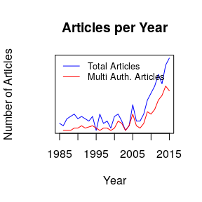

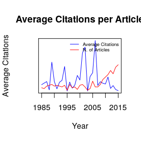

**Most Productive Authors**

| Authors | Articles | Authors | Articles Fractionalized |
| --- | --- | --- | --- |
| BORNMANN,L | 8 | BORNMANN,L | 4.67 |
| KOSTOFF,R | 8 | MARX,W | 3.17 |
| MARX,W | 6 | ATKINSON,R | 3.00 |
| GLANZEL,W | 5 | BROADUS,R | 3.00 |
| HUMENIK,J | 5 | CRONIN,B | 3.00 |
| ABRAMO,G | 4 | BORGMAN,C | 2.50 |
| D’ANGELO,CA | 4 | MCCAIN,K | 2.50 |
| ATKINSON,R | 3 | PERITZ,B | 2.50 |
| BARKER,K | 3 | KOSTOFF,R | 2.10 |
| BORGMAN,C | 3 | ADAMS,J | 2.00 |

**Top Manuscripts**

| Paper | TC | TCperYear |
| --- | --- | --- |
| DAIM TU;RUEDA G;MARTIN H;GERDSRI P,(2006),TECHNOL. FORECAST. SOC. CHANG. | 211 | 19.18 |
| WHITE H;MCCAIN K,(1989),ANNU. REV. INFORM. SCI. TECHNOL. | 196 | 7.00 |
| BORGMAN C;FURNER J,(2002),ANNU. REV. INFORM. SCI. TECHNOL. | 192 | 12.80 |
| WEINGART P,(2005),SCIENTOMETRICS | 151 | 12.58 |
| NARIN F,(1994),SCIENTOMETRICS | 141 | 6.13 |
| CRONIN B,(2001),J. INF. SCI. | 129 | 8.06 |
| CHEN Y;YEH H;WU J;HASCHLER I;CHEN T;WETTER T,(2011),SCIENTOMETRICS | 101 | 16.83 |
| HOOD W;WILSON C,(2001),SCIENTOMETRICS | 71 | 4.44 |
| D’ANGELO CA;GIUFFRIDA C;ABRAMO G,(2011),J. AM. SOC. INF. SCI. TECHNOL. | 64 | 10.67 |
| NARIN F;OLIVASTRO D;STEVENS K,(1994),EVAL. REV. | 62 | 2.70 |

**Most Productive Countries**

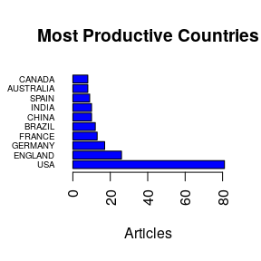

**Total Citations per Country**

| Country | Total Citations | Average Article Citations |
| --- | --- | --- |
| USA | 1831 | 22.60 |
| GERMANY | 330 | 19.41 |
| ITALY | 163 | 32.60 |
| AUSTRALIA | 134 | 16.75 |
| ENGLAND | 121 | 4.65 |
| CANADA | 111 | 13.88 |
| INDIA | 85 | 8.50 |
| SPAIN | 85 | 9.44 |
| IRAN | 74 | 37.00 |
| BELGIUM | 70 | 10.00 |

**Most Relevant Sources**

| Sources | Articles |
| --- | --- |
| SCIENTOMETRICS | 49 |
| JOURNAL OF THE AMERICAN SOCIETY FOR INFORMATION SCIENCE AND TECHNOLOGY | 14 |
| JOURNAL OF THE AMERICAN SOCIETY FOR INFORMATION SCIENCE | 8 |
| JOURNAL OF DOCUMENTATION | 6 |
| JOURNAL OF INFORMATION SCIENCE | 6 |
| JOURNAL OF INFORMETRICS | 6 |
| BRITISH JOURNAL OF ANAESTHESIA | 5 |
| LIBRI | 5 |
| SOCIAL WORK IN HEALTH CARE | 5 |
| TECHNOLOGICAL FORECASTING AND SOCIAL CHANGE | 5 |

**Most Related Keywords**

| Author Keywords (DE) | Articles | Keywords-Plus (ID) | Articles |
| --- | --- | --- | --- |
| BIBLIOMETRICS | 63 | SCIENCE | 38 |
| CITATION ANALYSIS | 11 | INDICATORS | 24 |
| SCIENTOMETRICS | 7 | IMPACT | 23 |
| IMPACT FACTOR | 5 | CITATION | 20 |
| INFORMATION RETRIEVAL | 5 | CITATION ANALYSIS | 15 |
| PEER REVIEW | 5 | JOURNALS | 14 |
| CITATION | 4 | H-INDEX | 13 |
| CITATIONS | 4 | PUBLICATION | 12 |
| H-INDEX | 4 | INFORMATION-SCIENCE | 10 |
| IMPACT FACTORS | 4 | IMPACT FACTORS | 8 |

## Authors’ Dominance ranking

The function dominance calculates the authors’ dominance ranking as proposed by Kumar & Kumar, 2008.

|  | Dominance Factor | Multi Authored | First Authored | Rank by Articles | Rank by DF |
| --- | --- | --- | --- | --- | --- |
| KOSTOFF,R | 1.0000000 | 8 | 8 | 2 | 1 |
| HOLDEN,G | 1.0000000 | 3 | 3 | 9 | 2 |
| ABRAMO,G | 0.7500000 | 4 | 3 | 5 | 3 |
| GARG,K | 0.6666667 | 3 | 2 | 8 | 4 |
| MOPPETT,IK | 0.6666667 | 3 | 2 | 10 | 5 |
| BORNMANN,L | 0.6250000 | 8 | 5 | 1 | 6 |
| GLANZEL,W | 0.6000000 | 5 | 3 | 4 | 7 |
| BORGMAN,C | 0.3333333 | 3 | 1 | 7 | 8 |
| D’ANGELO,CA | 0.2500000 | 4 | 1 | 6 | 9 |
| MARX,W | 0.1666667 | 6 | 1 | 3 | 10 |

## Authors’ h-index

The h-index is an author-level metric that attempts to measure both the productivity and citation impact of the publications of a scientist or scholar.

```r
authors=gsub(","," ",names(df$Authors)[1:10])

indices <- Hindex(database, authors, sep = ";",years=50)

knitr::kable(indices$H)
```

| Author | h_index | g_index | m_index | TC | NP |
| --- | --- | --- | --- | --- | --- |
| BORNMANN L | 4 | 7 | 0.6666667 | 50 | 8 |
| KOSTOFF R | 8 | 8 | 0.4210526 | 276 | 8 |
| MARX W | 3 | 6 | 0.4285714 | 36 | 6 |
| GLANZEL W | 2 | 5 | 0.0833333 | 64 | 5 |
| HUMENIK J | 5 | 5 | 0.2777778 | 213 | 5 |
| ABRAMO G | 4 | 4 | 0.4444444 | 158 | 4 |
| D’ANGELO CA | 4 | 4 | 0.4444444 | 158 | 4 |
| ATKINSON R | 0 | 0 | 0.0000000 | 0 | 3 |
| BARKER K | 3 | 3 | 0.2307692 | 61 | 3 |
| BORGMAN C | 3 | 3 | 0.1034483 | 225 | 3 |

## Lotka’s Law coefficient estimation

Lotka’s law describes the frequency of publication by authors in any given field as an inverse square law, where the number of authors publishing a certain number of articles is a fixed ratio to the number of authors publishing a single article.

```r
L <- lotka(df)
# Author Productivity. Empirical Distribution
knitr::kable(L$AuthorProd)
```

| N.Articles | N.Authors | Freq |
| --- | --- | --- |
| 1 | 467 | 0.8696462 |
| 2 | 49 | 0.0912477 |
| 3 | 14 | 0.0260708 |
| 4 | 2 | 0.0037244 |
| 5 | 2 | 0.0037244 |
| 6 | 1 | 0.0018622 |
| 8 | 2 | 0.0037244 |

## Bibliometric network matrices

## Bibliographic coupling

[figure not shown]

```r
NetMatrix <- biblioNetwork(database, analysis = "coupling", network = "authors", sep = ";")

# calculate jaccard similarity coefficient
S <- normalizeSimilarity(NetMatrix, type="jaccard")

# plot authors' similarity (first 20 authors)
net=networkPlot(S, n = 10, Title = "Authors' Coupling", type = "fruchterman", size=FALSE,remove.multiple=TRUE)
```

## Bibliographic co-citation